# stitches in R

# IMPORTANT NOTES

- Necessary to avoid R variable names like `variable.name` since `.` in python is somewhat analogous to `$` in R.
- Follow the instructions in the `stitches-in-R-setup` R markdown so that this notebook will work. If you’ve followed that markdown, `stitches` should be installed in the `r-reticulate` virtual environment for this notebook and should be callable.

# Setup

## R

```r
#### R  BLOCK ####
library(reticulate)
# # indicate that we want to use a specific virtualenv
use_virtualenv("r-reticulate", required =TRUE)


library(dplyr)
```

```r
library(tidyr)
library(ggplot2)

# time slice for the map plotting:
map_time <- '2100-12-31'
```

## python

```python
#### Python Block ####
import stitches
import pandas as pd
import pkg_resources
import xarray as xr
import numpy as np
pd.set_option('display.max_columns', None)


# The CMIP6 ESM we want to emulate and the variables we want to
# emulate
esm = ['CanESM5']
vars1 = ['tas', 'pr', 'hurs', 'psl']
```

# Load Hector data

pulled a quick rcp4.5 from HectorUI

```r
#### R  BLOCK ####
hector_tgav <- read.csv('data/Hector-data-2022-09-22.csv', skip=3, stringsAsFactors = FALSE)
hector_exp <- unique(hector_tgav$scenario)
head(hector_tgav)
```

```
##                scenario year variable     value units
## 1 RCP  Standard-RCP-4.5 1800     Tgav 0.1176974  degC
## 2 RCP  Standard-RCP-4.5 1801     Tgav 0.1212491  degC
## 3 RCP  Standard-RCP-4.5 1802     Tgav 0.1243894  degC
## 4 RCP  Standard-RCP-4.5 1803     Tgav 0.1272345  degC
## 5 RCP  Standard-RCP-4.5 1804     Tgav 0.1298589  degC
## 6 RCP  Standard-RCP-4.5 1805     Tgav 0.1323124  degC
```

# Reshape the Hector data to be stitches target

First we reshape the Hector time series to match the CMIP6 ESM GSAT smooth anomaly time series that STITCHES operates on: NOTE we should probably add this as a function to stitches NOTE Hector time series start in 1800 - there’s no science reason we couldn’t do matching over that window and have a gridded netcdf of an extra 50 years of history.

```r
#### R  BLOCK ####
hector_tgav %>%
    mutate(variable = 'tas',
           ensemble = 'hectorUI1',# doesn't affect the matching or stitching
           model = 'Hector') %>%
    rename(experiment = scenario) %>%
    filter(year >= 1850) %>%
    select(variable, experiment, ensemble, model, year, value,  -units) ->
    target_tgav

print(head(target_tgav))
```

```
##   variable            experiment  ensemble  model year      value
## 1      tas RCP  Standard-RCP-4.5 hectorUI1 Hector 1850 0.08854785
## 2      tas RCP  Standard-RCP-4.5 hectorUI1 Hector 1851 0.09338570
## 3      tas RCP  Standard-RCP-4.5 hectorUI1 Hector 1852 0.09959573
## 4      tas RCP  Standard-RCP-4.5 hectorUI1 Hector 1853 0.10672673
## 5      tas RCP  Standard-RCP-4.5 hectorUI1 Hector 1854 0.11386913
## 6      tas RCP  Standard-RCP-4.5 hectorUI1 Hector 1855 0.10890346
```

# Convert Hector Tgav to stitches windows

Now that we have shaped it as stitches is expecting, we can use stitches functions to calculate the matching windows for this target data

```python
#### Python Block ####
# smooth out Hector's historic volcano stuff and
# save off the smoothed Hector time series we actually use for matching so can plot later:
target_hector = stitches.fx_processing.calculate_rolling_mean(r.target_tgav, size =31)
target_data = stitches.fx_processing.get_chunk_info(
    stitches.fx_processing.chunk_ts(df = target_hector,  n=9))
```

[output not shown]

[output cut: 9 more lines]

[output not shown]

```python
print(target_data.head())
```

```
##               experiment   model   ensemble variable  start_yr  end_yr  year  \
## 0  RCP  Standard-RCP-4.5  Hector  hectorUI1      tas      1850    1858  1854
## 1  RCP  Standard-RCP-4.5  Hector  hectorUI1      tas      1859    1867  1863
## 2  RCP  Standard-RCP-4.5  Hector  hectorUI1      tas      1868    1876  1872
## 3  RCP  Standard-RCP-4.5  Hector  hectorUI1      tas      1877    1885  1881
## 4  RCP  Standard-RCP-4.5  Hector  hectorUI1      tas      1886    1894  1890
##
##          fx        dx
## 0  0.078261  0.002583
## 1  0.098307  0.001913
## 2  0.081917 -0.003862
## 3  0.067267 -0.001180
## 4  0.047476 -0.003127
```

```python
print(target_data.head())
```

```
##               experiment   model   ensemble variable  start_yr  end_yr  year  \
## 0  RCP  Standard-RCP-4.5  Hector  hectorUI1      tas      1850    1858  1854
## 1  RCP  Standard-RCP-4.5  Hector  hectorUI1      tas      1859    1867  1863
## 2  RCP  Standard-RCP-4.5  Hector  hectorUI1      tas      1868    1876  1872
## 3  RCP  Standard-RCP-4.5  Hector  hectorUI1      tas      1877    1885  1881
## 4  RCP  Standard-RCP-4.5  Hector  hectorUI1      tas      1886    1894  1890
##
##          fx        dx
## 0  0.078261  0.002583
## 1  0.098307  0.001913
## 2  0.081917 -0.003862
## 3  0.067267 -0.001180
## 4  0.047476 -0.003127
```

# Load the stitches archive data for matching

```
##        ensemble variable    model experiment  start_yr  end_yr  year  \
## 6996  r10i1p1f1      tas  CanESM5     ssp126      1850    1858  1854
## 6997  r10i1p1f1      tas  CanESM5     ssp126      1859    1867  1863
## 6998  r10i1p1f1      tas  CanESM5     ssp126      1868    1876  1872
## 6999  r10i1p1f1      tas  CanESM5     ssp126      1877    1885  1881
## 7000  r10i1p1f1      tas  CanESM5     ssp126      1886    1894  1890
##
##             fx        dx
## 6996 -1.360399  0.016472
## 6997 -1.297474 -0.001508
## 6998 -1.200856  0.010901
## 6999 -1.218503 -0.016847
## 7000 -1.285527  0.006000
```

# Match

```python
#### python block ####
my_recipes = stitches.make_recipe(target_data, archive_data,
                                  non_tas_variables=['pr', 'psl', 'hurs'],
                                  tol = 0.14, N_matches = 10000,
                                  reproducible = True)
```

```
## You have requested more recipes than possible for at least one target trajectories, returning what can
```

```python
print(my_recipes.head())
```

```
##   target_start_yr target_end_yr archive_experiment archive_variable  \
## 0            1850          1858         historical              tas
## 1            1859          1867         historical              tas
## 2            1868          1876         historical              tas
## 3            1877          1885         historical              tas
## 4            1886          1894         historical              tas
##
##   archive_model archive_ensemble                       stitching_id  \
## 0       CanESM5        r24i1p1f1  RCP  Standard-RCP-4.5~hectorUI1~1
## 1       CanESM5        r24i1p1f1  RCP  Standard-RCP-4.5~hectorUI1~1
## 2       CanESM5        r24i1p1f1  RCP  Standard-RCP-4.5~hectorUI1~1
## 3       CanESM5        r14i1p1f1  RCP  Standard-RCP-4.5~hectorUI1~1
## 4       CanESM5         r8i1p1f1  RCP  Standard-RCP-4.5~hectorUI1~1
##
##   archive_start_yr archive_end_yr  \
```

[output cut: 33 more lines]

Unless otherwise specified by the argument `reproducible = True`, the draws stitches takes from the pool of matches is stochastic.

Within each of these ensembles, there’s no envelope collapse. If we were to concatenate them together into a super-ensemble, there would be. So it’s not as powerful as a very large ensemble of collapse free realizations but it’s still a distinct ensemble to consider.

# stitch Tgav

```python
#### python block ####
stitched_global_temp = stitches.gmat_stitching(my_recipes)
print(stitched_global_temp.head())
```

```
##    year     value variable                       stitching_id
## 0  1850  0.106926      tas  RCP  Standard-RCP-4.5~hectorUI1~1
## 1  1851  0.154738      tas  RCP  Standard-RCP-4.5~hectorUI1~1
## 2  1852  0.118152      tas  RCP  Standard-RCP-4.5~hectorUI1~1
## 3  1853  0.094706      tas  RCP  Standard-RCP-4.5~hectorUI1~1
## 4  1854  0.024321      tas  RCP  Standard-RCP-4.5~hectorUI1~1
```

# plot Tgav

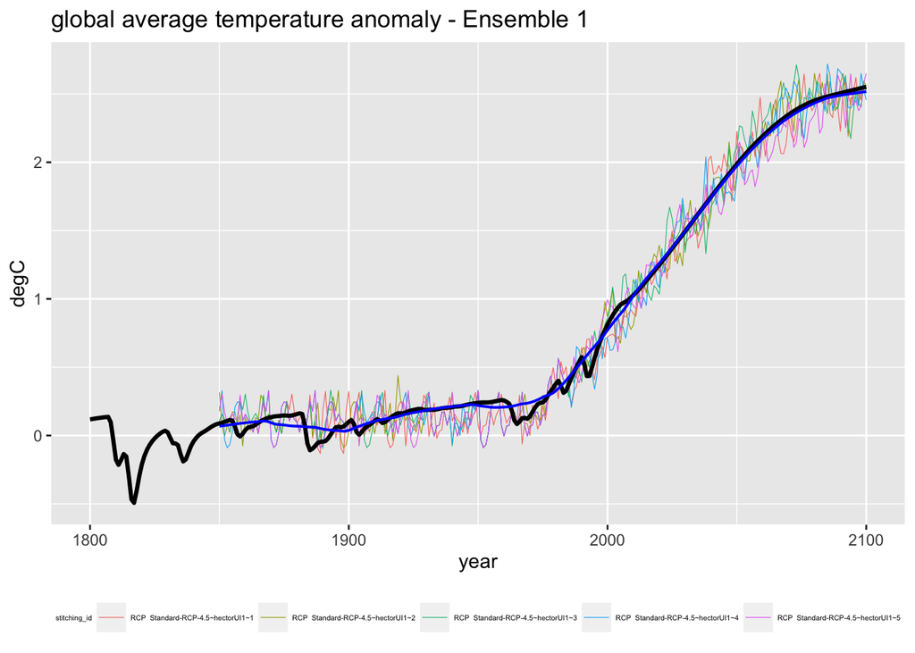

# stitch gridded

Using the above recipes, stitches can produce new gridded netcdf files for each recipe, for multiple variables. Creating multiple netcdfs of monthly data is slower than focusing on GSAT. Still much faster than an ESM, and once the recipes are set, very parallelizable. But for tractability, we are just going to stitch the gridded netcdfs for one generated ensemble member.

```python
#### python block ####
# Just do one realization
recipe = my_recipes[my_recipes['stitching_id'] == 'RCP  Standard-RCP-4.5~hectorUI1~1'].reset_index(drop=True).copy()
```

We must specify a directory for the netcdfs to be saved to. We will use simply do it directly here. On my computer, constructing these 4 netcdfs took ~2-3 minutes.

```python
#### python block ####
stitches.gridded_stitching(out_dir='data', rp =recipe)
```

```
## ['Stitching gridded netcdf for: CanESM5 tas RCP  Standard-RCP-4.5~hectorUI1~1']
## ['data/stitched_CanESM5_tas_RCP  Standard-RCP-4.5~hectorUI1~1.nc', 'data/stitched_CanESM5_hurs_RCP  Standard-RCP-4.5~hectorUI1~1.nc', 'data/stitched_CanESM5_pr_RCP  Standard-RCP-4.5~hectorUI1~1.nc', 'data/stitched_CanESM5_psl_RCP  Standard-RCP-4.5~hectorUI1~1.nc']
```

# plot gridded setup

- we will do maps of all 4 variables at a specified month and year
- we will do a time series of each variable in a specific grid cell

```
## [1] "data/stitched_CanESM5_hurs_RCP  Standard-RCP-4.5~hectorUI1~1.nc"
## [2] "data/stitched_CanESM5_pr_RCP  Standard-RCP-4.5~hectorUI1~1.nc"
## [3] "data/stitched_CanESM5_psl_RCP  Standard-RCP-4.5~hectorUI1~1.nc"
## [4] "data/stitched_CanESM5_tas_RCP  Standard-RCP-4.5~hectorUI1~1.nc"
```

It’s a lot easier to use python to load in the netcdfs and select a grid cell or a time slice, save those off as simpler data frames than a full netcdf, and plot in R. The reshaping set of code that we often do in R to work with netcdf data is just so much faster if we’ve pre-sliced the data to a single grid cell or single time step in python.

# tas

```python
#### python block ####
[tas_time_slice, tas_grid_slice] = select_time_grid_slice(varname='tas')
```

Take a look at this data in R and plot it

```
## <xarray.DataArray 'tas' (lat: 64, lon: 128)>
## array([[254.30795, 254.17578, 254.08174, ..., 254.75458, 254.60829, 254.46349],
##        [253.8553 , 253.59615, 253.33083, ..., 254.7608 , 254.42699, 254.12904],
##        [253.60722, 253.49982, 253.27187, ..., 254.4661 , 254.13226, 253.84972],
##        ...,
##        [264.6031 , 266.82492, 269.47043, ..., 259.50638, 260.95352, 262.70947],
##        [266.73386, 267.68997, 268.77417, ..., 264.11572, 264.92725, 265.84232],
##        [269.5461 , 270.08945, 270.48822, ..., 268.0271 , 268.54642, 268.96014]],
##       dtype=float32)
## Coordinates:
##     time     datetime64[ns] 2100-12-31
##   * lat      (lat) float64 -87.86 -85.1 -82.31 -79.53 ... 79.53 82.31 85.1 87.86
##   * lon      (lon) float64 0.0 2.812 5.625 8.438 ... 348.8 351.6 354.4 357.2
## Attributes:
##     units:            K
##     variable:         tas
##     experiment:       historical
##     ensemble:         r24i1p1f1
##     model:            CanESM5
##     stitching_id:     RCP  Standard-RCP-4.5~hectorUI1~1
##     recipe_location:  data/stitched_CanESM5_tas_RCP  Standard-RCP-4.5~hectorU...
```

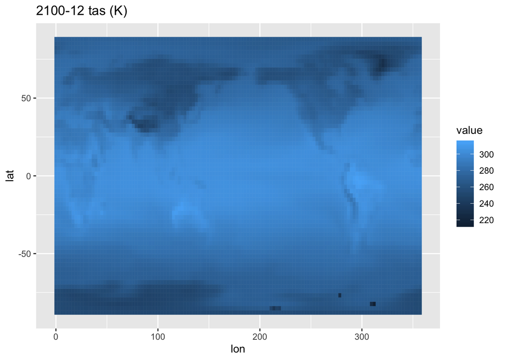

```
## <xarray.DataArray 'tas' (time: 3000)>
## array([267.57404, 267.1224 , 273.28598, ..., 289.05472, 279.37387, 271.70584],
##       dtype=float32)
## Coordinates:
##   * time     (time) datetime64[ns] 1850-01-31 1850-02-28 ... 2099-12-31
##     lat      float64 37.67
##     lon      float64 255.9
## Attributes:
##     units:            K
##     variable:         tas
##     experiment:       historical
##     ensemble:         r24i1p1f1
##     model:            CanESM5
##     stitching_id:     RCP  Standard-RCP-4.5~hectorUI1~1
##     recipe_location:  data/stitched_CanESM5_tas_RCP  Standard-RCP-4.5~hectorU...
```

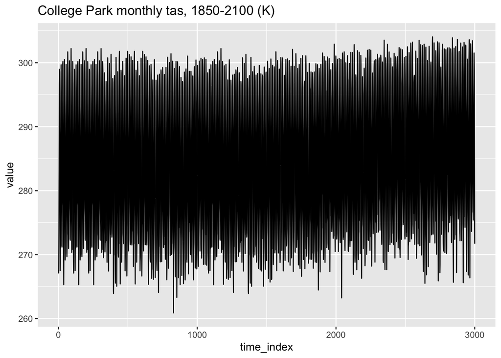

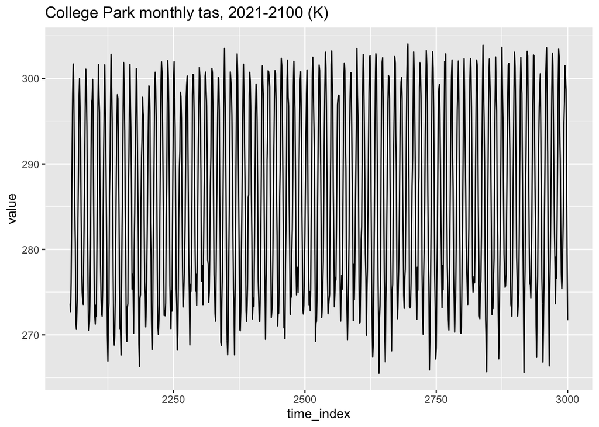

# pr

```python
#### python block ####
[pr_time_slice, pr_grid_slice] = select_time_grid_slice(varname='pr')
```

Take a look at this data in R:

```
## <xarray.DataArray 'pr' (lat: 64, lon: 128)>
## array([[1.417732e-06, 1.276476e-06, 1.297603e-06, ..., 1.428884e-06,
##         1.477538e-06, 1.393586e-06],
##        [3.486665e-06, 2.949829e-06, 2.711167e-06, ..., 4.569446e-06,
##         4.239449e-06, 3.826327e-06],
##        [4.728726e-06, 4.308512e-06, 3.682548e-06, ..., 6.689132e-06,
##         5.677356e-06, 4.844569e-06],
##        ...,
##        [8.842010e-06, 6.820415e-06, 6.429561e-06, ..., 8.141647e-06,
##         9.506348e-06, 8.408015e-06],
##        [7.630876e-06, 7.600152e-06, 7.877312e-06, ..., 9.542448e-06,
##         9.305504e-06, 8.593833e-06],
##        [1.258721e-05, 1.284911e-05, 1.330991e-05, ..., 1.256335e-05,
##         1.272361e-05, 1.256633e-05]], dtype=float32)
## Coordinates:
##     time     datetime64[ns] 2100-12-31
##   * lat      (lat) float64 -87.86 -85.1 -82.31 -79.53 ... 79.53 82.31 85.1 87.86
##   * lon      (lon) float64 0.0 2.812 5.625 8.438 ... 348.8 351.6 354.4 357.2
## Attributes:
##     units:            kg m-2 s-1
##     variable:         pr
##     experiment:       historical
##     ensemble:         r24i1p1f1
##     model:            CanESM5
##     stitching_id:     RCP  Standard-RCP-4.5~hectorUI1~1
##     recipe_location:  data/stitched_CanESM5_pr_RCP  Standard-RCP-4.5~hectorUI...
```

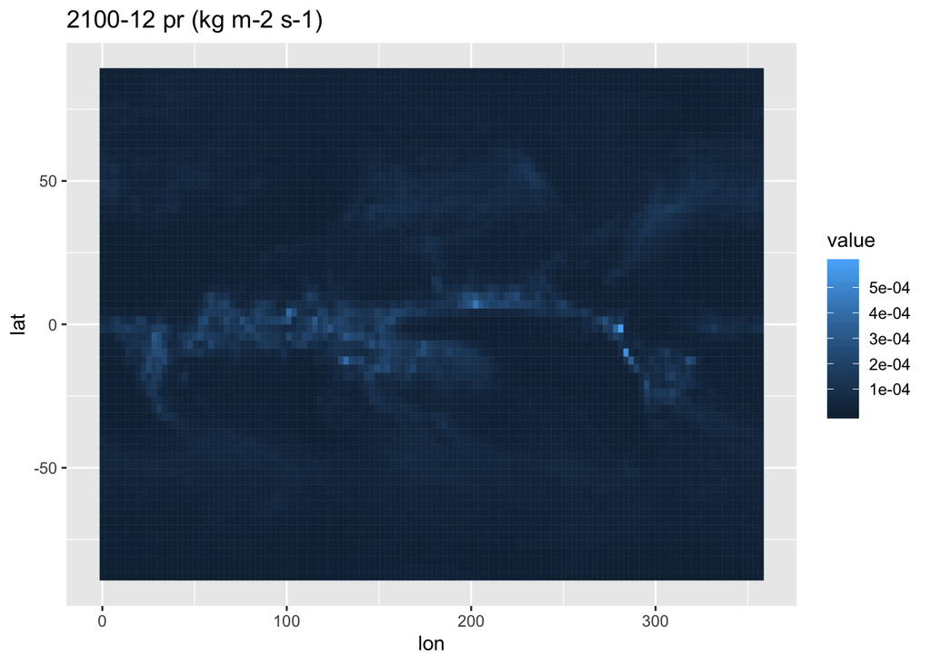

```
## <xarray.DataArray 'pr' (time: 3000)>
## array([8.414188e-06, 8.546974e-06, 5.744913e-06, ..., 1.655434e-05,
##        5.435949e-06, 8.619720e-06], dtype=float32)
## Coordinates:
##   * time     (time) datetime64[ns] 1850-01-31 1850-02-28 ... 2099-12-31
##     lat      float64 37.67
##     lon      float64 255.9
## Attributes:
##     units:            kg m-2 s-1
##     variable:         pr
##     experiment:       historical
##     ensemble:         r24i1p1f1
##     model:            CanESM5
##     stitching_id:     RCP  Standard-RCP-4.5~hectorUI1~1
##     recipe_location:  data/stitched_CanESM5_pr_RCP  Standard-RCP-4.5~hectorUI...
```

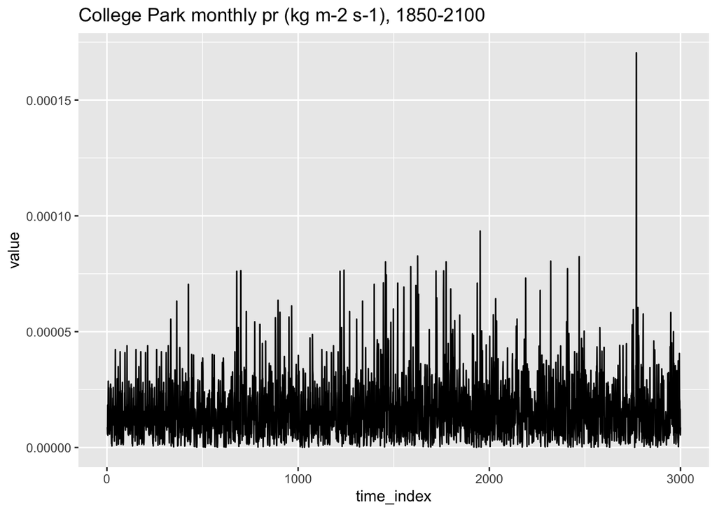

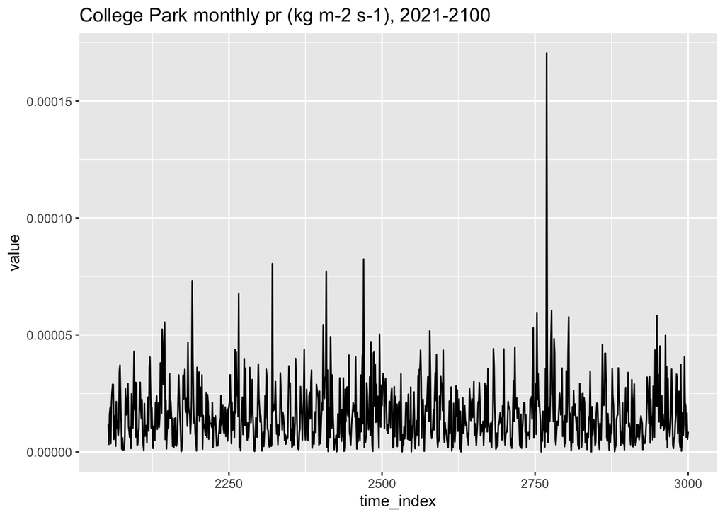

# hurs

```python
#### python block ####
[hurs_time_slice, hurs_grid_slice] = select_time_grid_slice(varname='hurs')
```

Take a look at this data in R:

```
## <xarray.DataArray 'hurs' (lat: 64, lon: 128)>
## array([[85.71909 , 85.91728 , 86.07451 , ..., 85.49169 , 85.7773  , 85.7175  ],
##        [88.977295, 89.11726 , 89.15314 , ..., 88.533134, 88.76999 , 88.90474 ],
##        [90.353516, 90.514046, 90.65683 , ..., 88.916565, 89.54906 , 89.98319 ],
##        ...,
##        [94.825516, 95.33015 , 97.08572 , ..., 95.52981 , 95.463165, 95.10121 ],
##        [96.02141 , 96.051056, 96.318756, ..., 95.8953  , 95.89552 , 95.967186],
##        [96.66825 , 97.07227 , 97.28846 , ..., 95.94691 , 96.17417 , 96.311424]],
##       dtype=float32)
## Coordinates:
##     time     datetime64[ns] 2100-12-31
##   * lat      (lat) float64 -87.86 -85.1 -82.31 -79.53 ... 79.53 82.31 85.1 87.86
##   * lon      (lon) float64 0.0 2.812 5.625 8.438 ... 348.8 351.6 354.4 357.2
## Attributes:
##     units:            %
##     variable:         hurs
##     experiment:       historical
##     ensemble:         r24i1p1f1
##     model:            CanESM5
##     stitching_id:     RCP  Standard-RCP-4.5~hectorUI1~1
##     recipe_location:  data/stitched_CanESM5_hurs_RCP  Standard-RCP-4.5~hector...
```

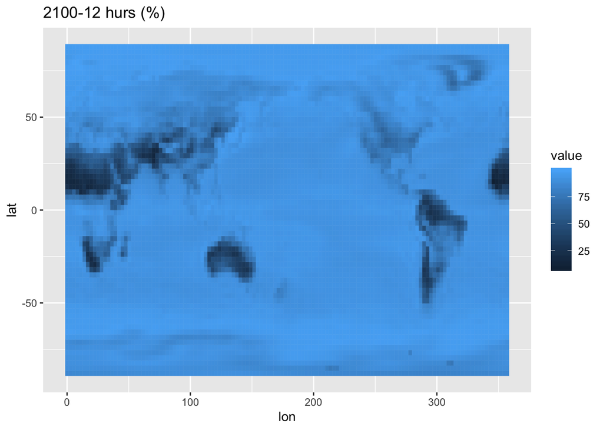

```
## <xarray.DataArray 'hurs' (time: 3000)>
## array([59.83445 , 61.397877, 58.244843, ..., 52.470364, 45.282383, 52.86437 ],
##       dtype=float32)
## Coordinates:
##   * time     (time) datetime64[ns] 1850-01-31 1850-02-28 ... 2099-12-31
##     lat      float64 37.67
##     lon      float64 255.9
## Attributes:
##     units:            %
##     variable:         hurs
##     experiment:       historical
##     ensemble:         r24i1p1f1
##     model:            CanESM5
##     stitching_id:     RCP  Standard-RCP-4.5~hectorUI1~1
##     recipe_location:  data/stitched_CanESM5_hurs_RCP  Standard-RCP-4.5~hector...
```

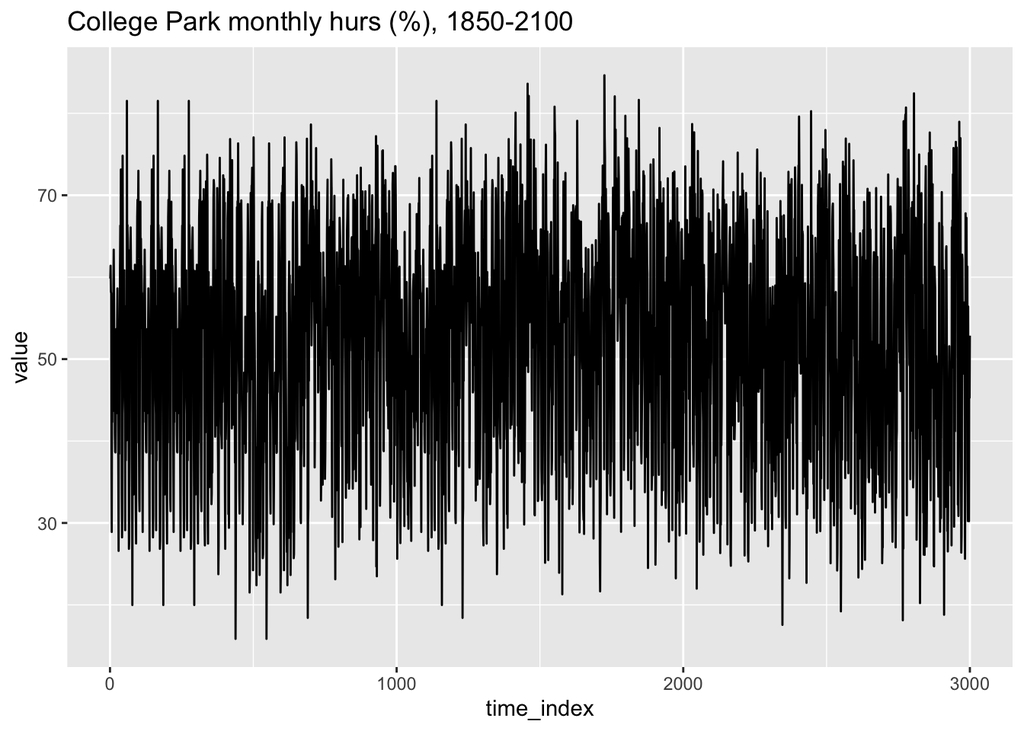

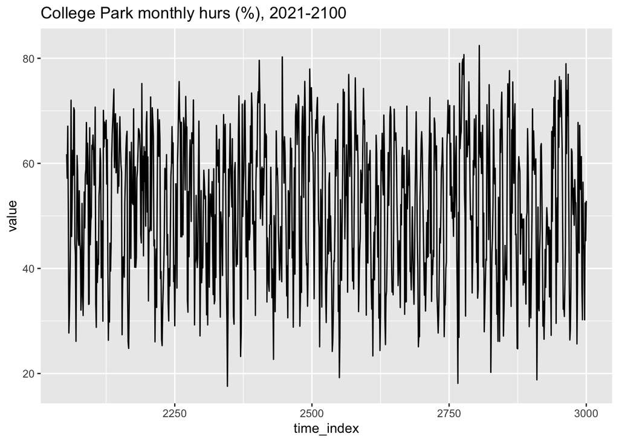

# psl

sea level pressure doesn’t make a ton of sense to plot for the grid slice

```python
#### python block ####
[psl_time_slice, psl_grid_slice] = select_time_grid_slice(varname='psl')
del(psl_grid_slice)
```

Take a look at this data in R:

```
## <xarray.DataArray 'psl' (lat: 64, lon: 128)>
## array([[ 99600.5  ,  99607.11 ,  99613.96 , ...,  99583.125,  99588.41 ,
##          99594.234],
##        [ 99613.45 ,  99645.95 ,  99675.305, ...,  99502.96 ,  99541.16 ,
##          99578.29 ],
##        [ 99561.9  ,  99581.555,  99597.83 , ...,  99481.16 ,  99511.49 ,
##          99538.55 ],
##        ...,
##        [100723.72 , 100666.33 , 100605.25 , ..., 100875.53 , 100827.695,
##         100777.37 ],
##        [100584.14 , 100549.41 , 100512.484, ..., 100674.016, 100646.51 ,
##         100616.54 ],
##        [100434.28 , 100421.93 , 100409.09 , ..., 100467.75 , 100457.24 ,
##         100446.07 ]], dtype=float32)
## Coordinates:
##     time     datetime64[ns] 2100-12-31
##   * lat      (lat) float64 -87.86 -85.1 -82.31 -79.53 ... 79.53 82.31 85.1 87.86
##   * lon      (lon) float64 0.0 2.812 5.625 8.438 ... 348.8 351.6 354.4 357.2
## Attributes:
##     units:            Pa
##     variable:         psl
##     experiment:       historical
##     ensemble:         r24i1p1f1
##     model:            CanESM5
##     stitching_id:     RCP  Standard-RCP-4.5~hectorUI1~1
##     recipe_location:  data/stitched_CanESM5_psl_RCP  Standard-RCP-4.5~hectorU...
```

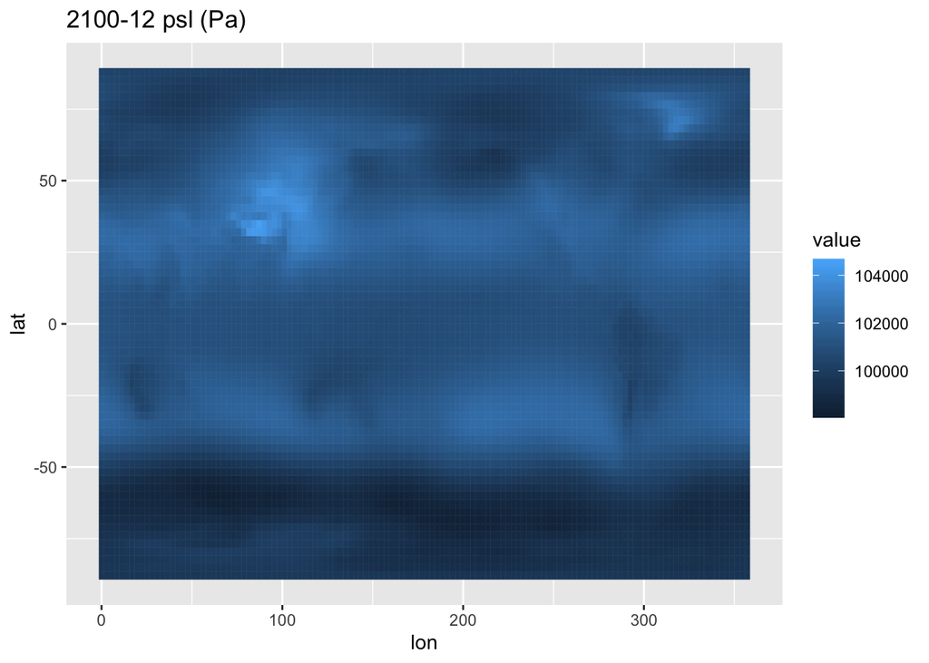